# Friends of the Normal Distribution

In Lecture 13 I introducted three distributions that are derived from the normal: Student-t, $\chi^2$ and $F$. This document uses simulations to, I hope, make these relationships a little clearer. This is the key point **all of these random variables arise from independent standard normals.**

### The $\chi^2(\nu)$ Random Variable

This is what you get if you take $\nu$ independent standard normals, square them, and sum the result. The paramter $\nu$ is called the “degrees of freedom.”

Let’s try creating some $\chi^2(1)$ random draws *the hard way* rather than using `rchisq`

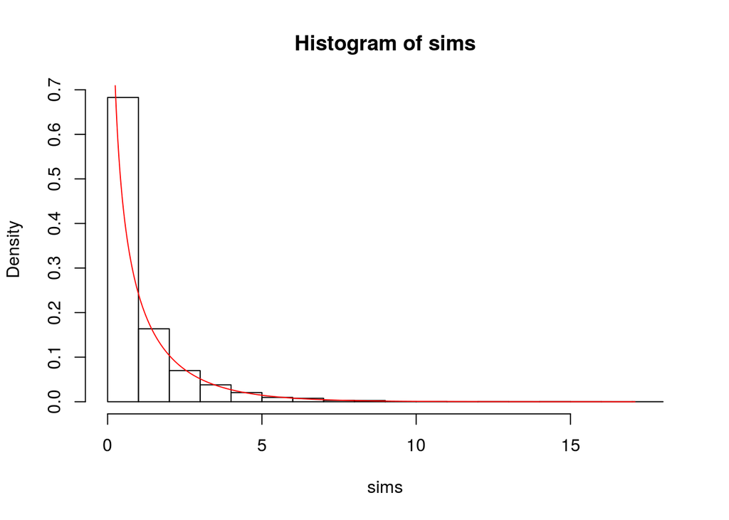

```r
#Function to draw a single Chi-squared random variable with degrees of freedom equal to df
my.rchisq <- function(df){

  #Draw df independent standard normals
  normal.sims <- rnorm(df)

  #Square them and sum the result
  chi.sims <- sum(normal.sims^2)

}

sims <- replicate(10000, my.rchisq(1))
hist(sims, probability = TRUE)
x <- seq(from = 0, to = max(sims), by = 0.01)
points(x, dchisq(x, df = 1), type = 'l', col = 'red')
```

It works! The histogram of simulations aligns almost perfectly with a plot of the *actual* density of a $\chi^2(1)$ random variable, which we got from `dchisq`.

Notice that I had to set `probability = TRUE` so that we got a histogram of relative frequencies rather than counts. Otherwise the scale of the histogram relative to the $\chi^2$ density would have been wrong.

We can try this again for a $\chi^2(5)$

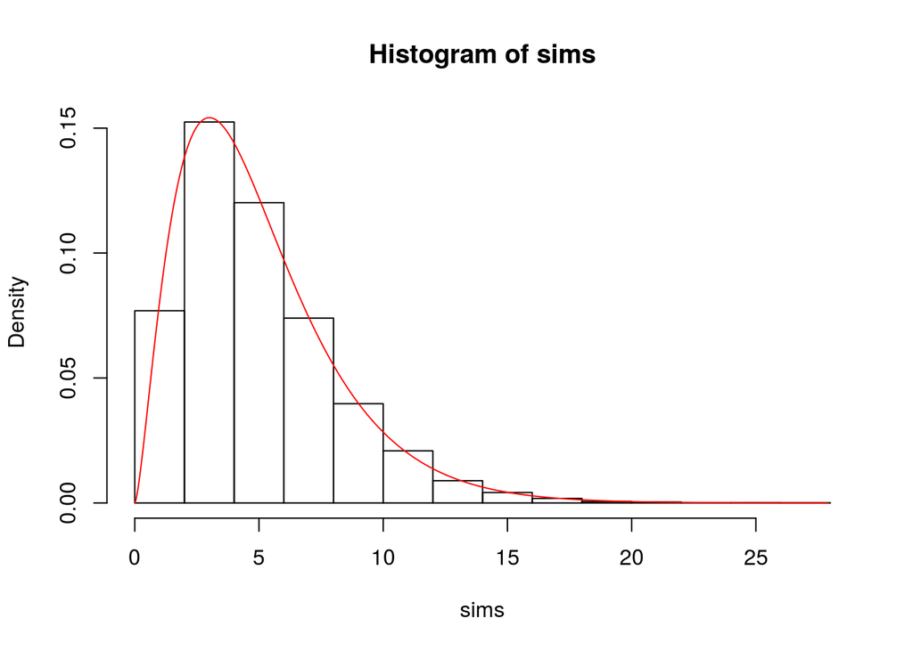

```r
sims <- replicate(10000, my.rchisq(5))
hist(sims, probability = TRUE)
x <- seq(from = 0, to = max(sims), by = 0.01)
points(x, dchisq(x, df = 5), type = 'l', col = 'red')
```

### The Student-t Random Variable

The Student-t distribution is built from the Normal and the $\chi^2$ so we can reuse `my.rchisq` from above:

```r
my.rt <- function(df){

  numerator <- rnorm(1)
  denominator <- sqrt( my.rchisq(df) / df )

  t.sim <- numerator/denominator
  return(t.sim)

}
```

Now we’ll try this out for a Student-t with one degree of freedom:

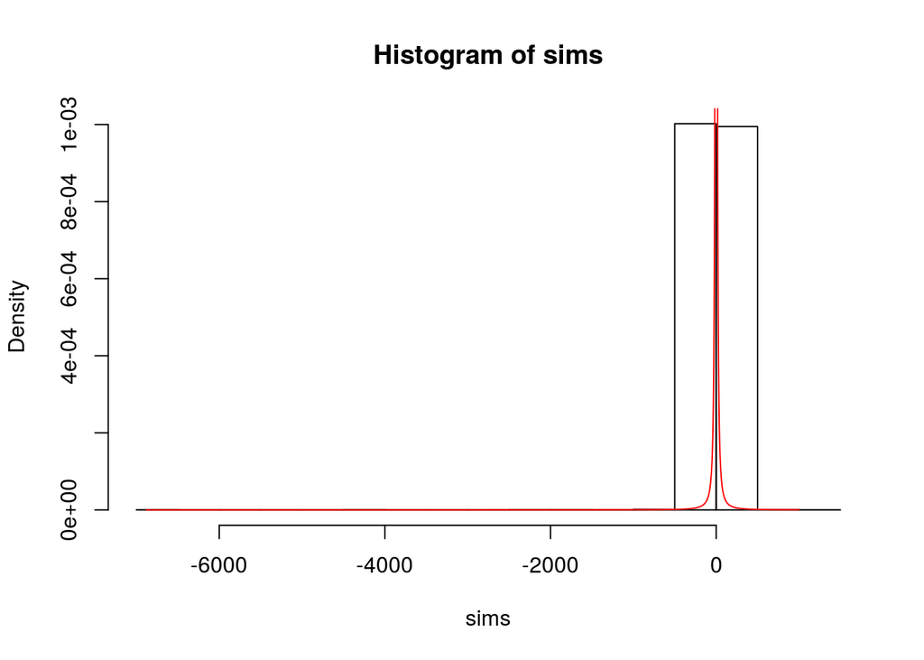

```r
sims <- replicate(10000, my.rt(1))
hist(sims, probability = TRUE)
x <- seq(from = min(sims), to = max(sims), by = 0.01)
points(x, dt(x, df = 1), type = 'l', col = 'red')
```

Wow! That looks weird! I told you in class that the Student-t distribution is really *wild*. What I meant was that it generates lots of “outliers” which is why the histogram looks so strange. We can “zoom in” on the region near zero by trimming out these outliers:

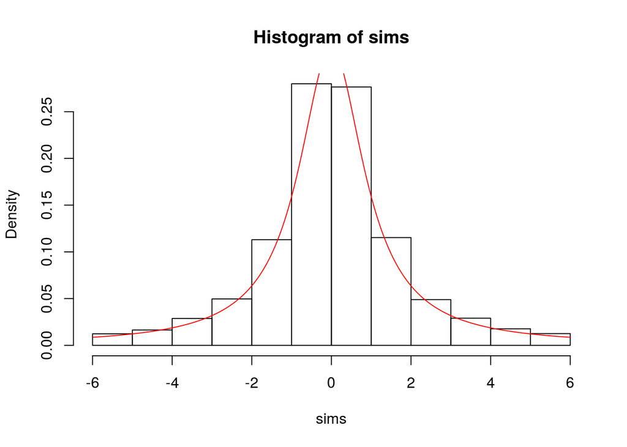

```r
sims <- subset(sims, -6 <= sims & sims <= 6)
hist(sims, probability = TRUE)
x <- seq(from = min(sims), to = max(sims), by = 0.01)
points(x, dt(x, df = 1), type = 'l', col = 'red')
```

Again we see that it works well. The Student-t gets much less *wild* when its degrees of freedom increase, so we don’t need to do any trimming to make the plot readable:

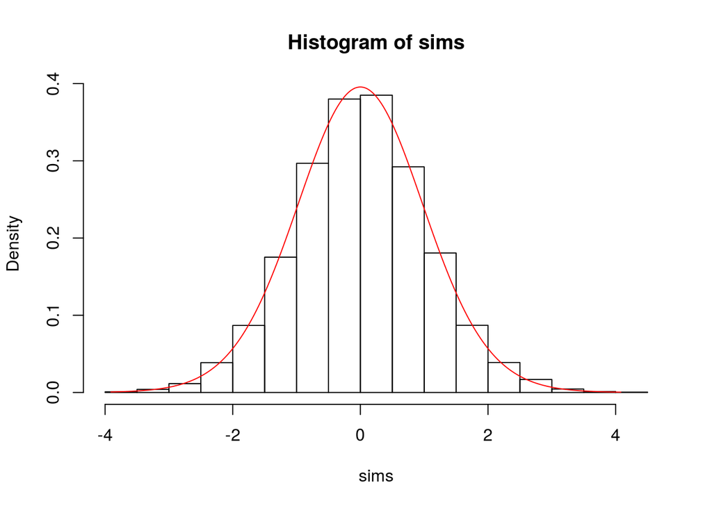

```r
sims <- replicate(10000, my.rt(30))
hist(sims, probability = TRUE)
x <- seq(from = min(sims), to = max(sims), by = 0.01)
points(x, dt(x, df = 30), type = 'l', col = 'red')
```

### The $F(\nu, \omega)$ Random Variable

Last but not least we have the $F$ random variable, which is defined as a ratio of independent $\chi^2$ random variables, each divided by their degrees of freedom. We’ll just use `my.rchisq` twice:

```r
my.rf <- function(numerator.df, denominator.df){

  numerator <- my.rchisq(numerator.df) / numerator.df
  denominator <- my.rchisq(denominator.df) / denominator.df

  f.sim <- numerator / denominator
  return(f.sim)

}
```

Finally, we’ll test this out for an $F(5,40)$ random variable

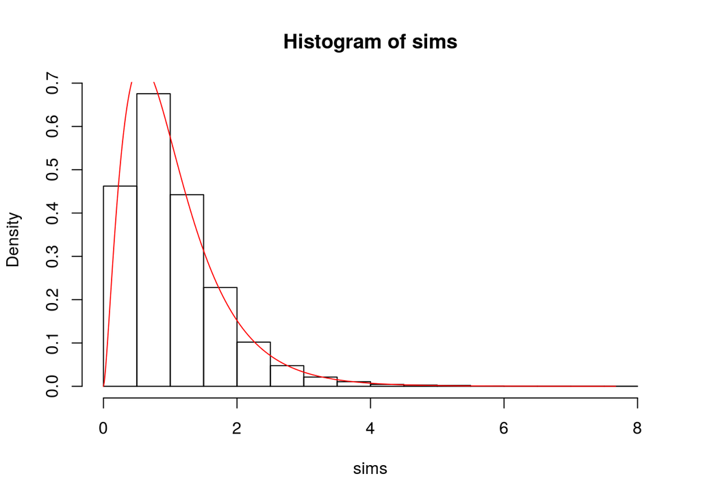

```r
sims <- replicate(10000, my.rf(5,40))
hist(sims, probability = TRUE)
x <- seq(from = 0, to = max(sims), by = 0.01)
points(x, df(x, df1 = 5, df2 = 40), type = 'l', col = 'red')
```

I hope this was helpful!